# Kannada AoA Study Milestone Report

Katrina May Dulay

15/04/2021

## Kannada AoA Study Milestone Report

This milestone report summarizes the results of the Kannada AoA study.

Milestone hit: N > 30. This report is based on data from 31 participants.

14 completed the old Qualtrics form and 17 completed the new Qualtrics form.

**Data errors were manually corrected with 3 participants due to:**

1. Wrong demographic entry: Parent marked self as expert
2. Missing ID due to Qualtrics login issues: RA manually filled up demographic + practice session [verified correct by Promise RA & Oxford RO]
3. Wrong demographic entry: Expert marked only disordered population

**Supporting documentation:**

1. Data dictionary
2. Word list properties (verified)
3. Data correction log (from RA documentation)

**Next steps:**

1. Milestone report for N = 50 and N = 74.
2. Interrater reliability computations.
3. Decision parameters for dropping words and participants, if any.
4. Analysis plan for AoA manuscript using mixed effect models.

### ELIGIBILITY VERIFICATION

During recruitment, participants self-declared their eligibility for one of the participant categories. Apart from the basic study requirements (e.g., Kannada proficiency, consent to participate), there are additional criteria that can be verified through the demographic questionnaire.

#### **Parents**

Inclusion criteria: * Must have a child who is at least 10 years or older.

```
##    Parent_Child1Age Parent_Child2Age
## 1                10               NA
## 2                12                7
## 3                11               NA
## 4                10               17
## 5                20               13
## 6                11                7
## 7                10               NA
## 8                13               NA
## 9                13               11
## 10               22               13
## 11               18               15
```

Parents had either 1 or 2 children; at least one of them is 10 years old or above. Therefore, all parent participants are confirmed to be eligible for the study.

#### **Teachers**

Inclusion criteria: * Must have at least 12 months of experience teaching children between 3 to 10 years.

```
##    Teacher_YrsExperience
## 1                     18
## 2                      2
## 3                     26
## 4                     27
## 5                     15
## 6                     23
## 7                     25
## 8                     10
## 9                      3
## 10                    14
## 11                    10
## 12                    10
```

Teachers are quite experienced, with a mean 15.25 years of experience, ranging between 2 to 27 years.

```
##    Presch LKG UKG 1st 2nd 3rd 4th 5th 6th 7th 8th-12th
## 1      NA  NA  NA  NA  NA   1  NA  NA  NA  NA       NA
## 2      NA   1   1  NA  NA  NA  NA  NA  NA  NA       NA
## 3      NA  NA  NA   1   1   1   1   1  NA  NA       NA
## 4      NA  NA  NA   1   1   1   1   1  NA  NA       NA
## 5      NA  NA   1   1   1   1   1  NA  NA  NA       NA
## 6      NA  NA  NA   1   1   1   1   1   1   1       NA
## 7       1   1   1  NA  NA  NA  NA  NA  NA  NA       NA
## 8      NA   1   1   1   1   1   1   1   1   1       NA
## 9      NA  NA  NA  NA  NA   1   1   1  NA  NA       NA
## 10     NA  NA   1  NA  NA  NA  NA  NA  NA  NA       NA
## 11     NA  NA  NA  NA  NA  NA   1   1   1   1        1
## 12     NA   1   1   1  NA  NA  NA  NA  NA  NA       NA
```

The 12 participants teach levels for children between 3 to 10 years. Therefore, all teacher participants are confirmed to be eligible for the study.

```
##                  SubjectsTaught
## 1             Kannada and Hindi
## 2                          <NA>
## 3                          <NA>
## 4                     HINDI, SS
## 5                Social Science
## 6                          <NA>
## 7                          <NA>
## 8                          <NA>
## 9                            No
## 10                           No
## 11                      English
## 12 Hindi, kannada, english ,evs
```

Among teachers that teach subjects, their subjects are Kannada, Hindi, English, and Social Science.

#### **Experts**

Inclusion criteria: * In the field of linguistics, speech-language pathology, psychology, developmental paediatrics, Kannada language, etc. * Must have at least 12 months of work experience with children aged 3 to 10 years. * Must have worked with typically-developing child populations (not only atypically-developing children).

```
##                                    ExpertField
## 1                           SPEECH AND HEARING
## 2 Early Childhood Education and Administration
## 3                             SPEECH PATHOLOGY
## 4      AUDIOLOGY AND SPEECH LANGUAGE PATHOLOGY
## 5                           Speech and Hearing
## 6      Home Science- Early Childhood Education
## 7                               Speech Hearing
## 8                                   Psychology
```

Experts work in speech and hearing, early childhood education, and psychology.

```
##   Expert_YrsExperience
## 1                    2
## 2                    8
## 3                    2
## 4                    2
## 5                    1
## 6                   25
## 7                    3
## 8                    4
```

Experts have at least 1 year of work experience with a mean 5.875 years of experience, ranging between 1 to 25 years.

```
##   Works with typical Works with atypical
## 1                  1                   1
## 2                  1                <NA>
## 3                  1                   1
## 4                  1                   1
## 5                  1                   1
## 6                  1                <NA>
## 7                  1                   1
## 8                  1                   1
```

Experts confirm that they work with typically-developing children.

Therefore, all experts are confirmed to be eligible for the study.

### WHO PARTICIPATED?

#### **Number of parents, teachers, and experts**

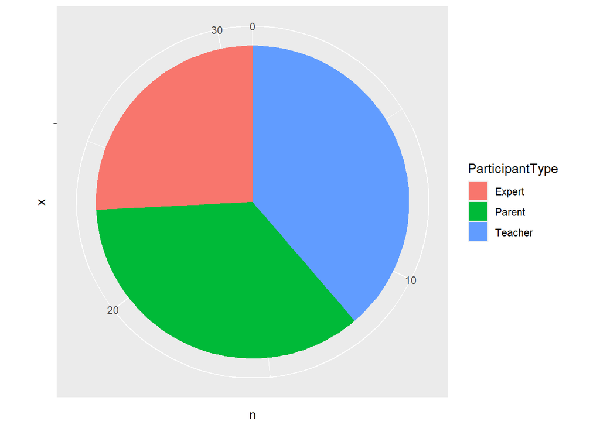

```
##   ParticipantType  n
## 1         Teacher 12
## 2          Parent 11
## 3          Expert  8
```

The target sample size is 70 with 21 parents, 28 teachers, and 21 experts.

#### **Gender**

*The sample is primarily female.*

```
##   Dem_Gender  n
## 1     Female 28
## 2       Male  3
```

Distribution of gender by participant type:

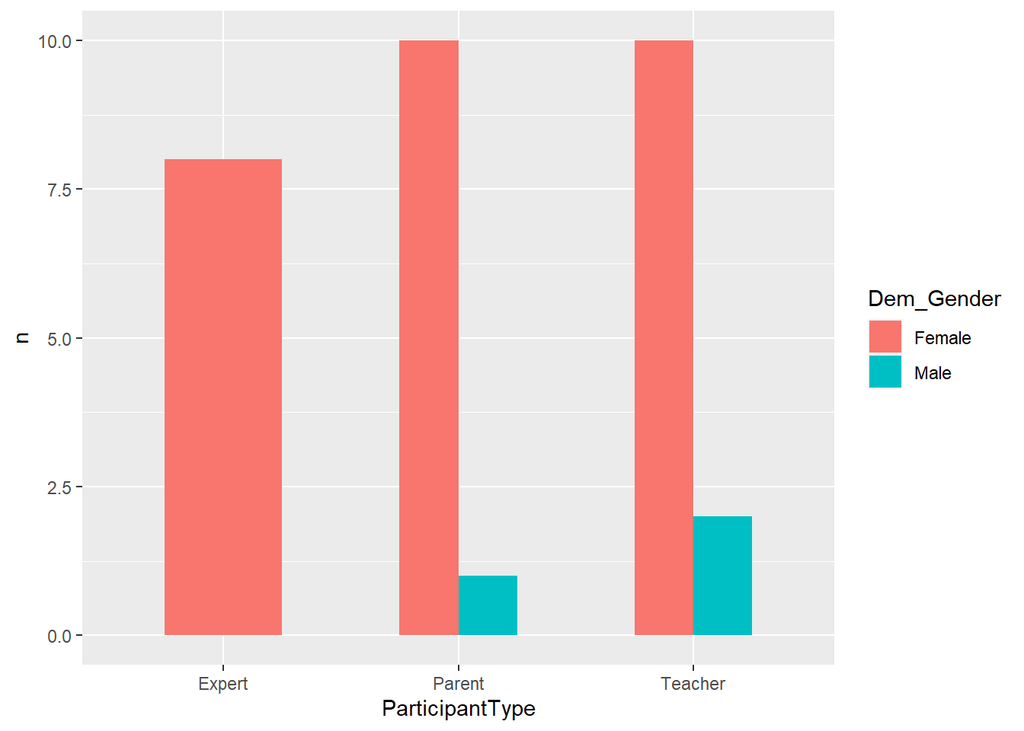

```
## # A tibble: 5 x 3
## # Groups:   ParticipantType [3]
##   ParticipantType Dem_Gender     n
##   <fct>           <fct>      <int>
## 1 Expert          Female         8
## 2 Parent          Female        10
## 3 Parent          Male           1
## 4 Teacher         Female        10
## 5 Teacher         Male           2
```

#### **Age of participants**

```
##   count  mean    sd min max
## 1    31 38.77 9.451  23  54
```

*Mean age is 38.7742.*

Distribution of age by participant type:

```
## # A tibble: 3 x 4
##   ParticipantType count  mean    sd
## * <fct>           <int> <dbl> <dbl>
## 1 Expert              8  30.2  9.63
## 2 Parent             11  41.3  5.83
## 3 Teacher            12  42.2  9.05
```

*One-way ANOVA results suggest significant group differences in age by participant type.*

```
## Levene's Test for Homogeneity of Variance (center = median)
##       Df F value Pr(>F)
## group  2    0.81   0.45
##       28
```

```
##                 Df Sum Sq Mean Sq F value Pr(>F)
## ParticipantType  2    788     394    5.83 0.0076 **
## Residuals       28   1891      68
## ---
## Signif. codes:  0 '***' 0.001 '**' 0.01 '*' 0.05 '.' 0.1 ' ' 1
```

Based on Tukey’s posthoc results:

*Experts are significantly younger than parents and teachers in the sample by around 10 years.*

```
##   Tukey multiple comparisons of means
##     95% family-wise confidence level
##
## Fit: aov(formula = Dem_AgeYears ~ ParticipantType, data = AoAData)
##
## $ParticipantType
##                   diff    lwr    upr  p adj
## Parent-Expert  11.0227  1.573 20.472 0.0197
## Teacher-Expert 11.9167  2.635 21.199 0.0098
## Teacher-Parent  0.8939 -7.595  9.383 0.9633
```

#### **Education level**

*Most participants have an undergraduate degree or higher.*

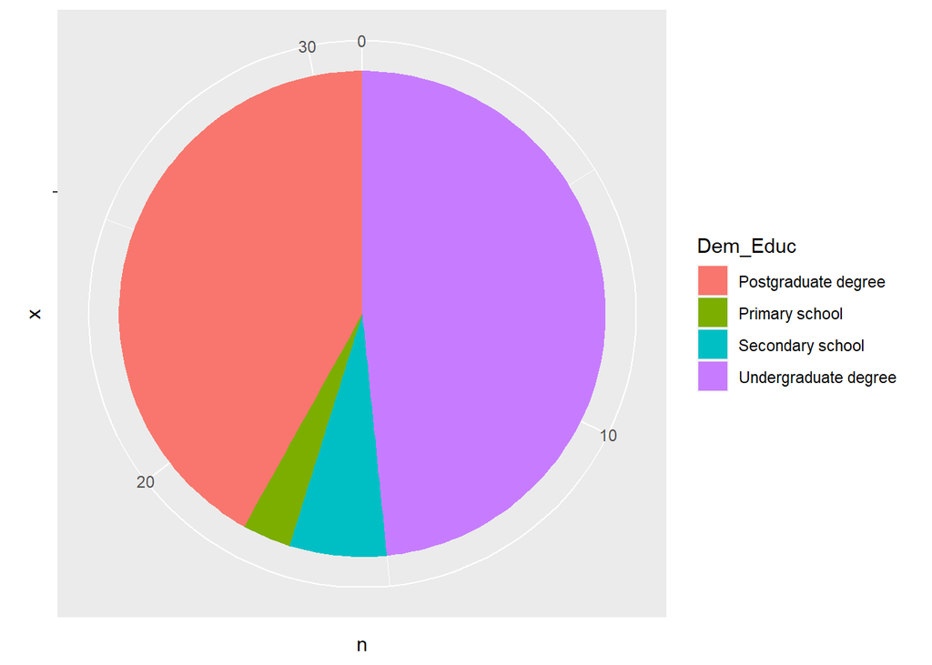

```
##               Dem_Educ  n
## 1 Undergraduate degree 15
## 2  Postgraduate degree 13
## 3     Secondary school  2
## 4       Primary school  1
```

*The mean education level is 3.2903.*

Value labels: 1 = Primary school 2 = Secondary school 3 = Undergraduate degree 4 = Postgraduate degree

```
##   count mean     sd min max
## 1    31 3.29 0.7391   1   4
```

Mean education levels by participant type:

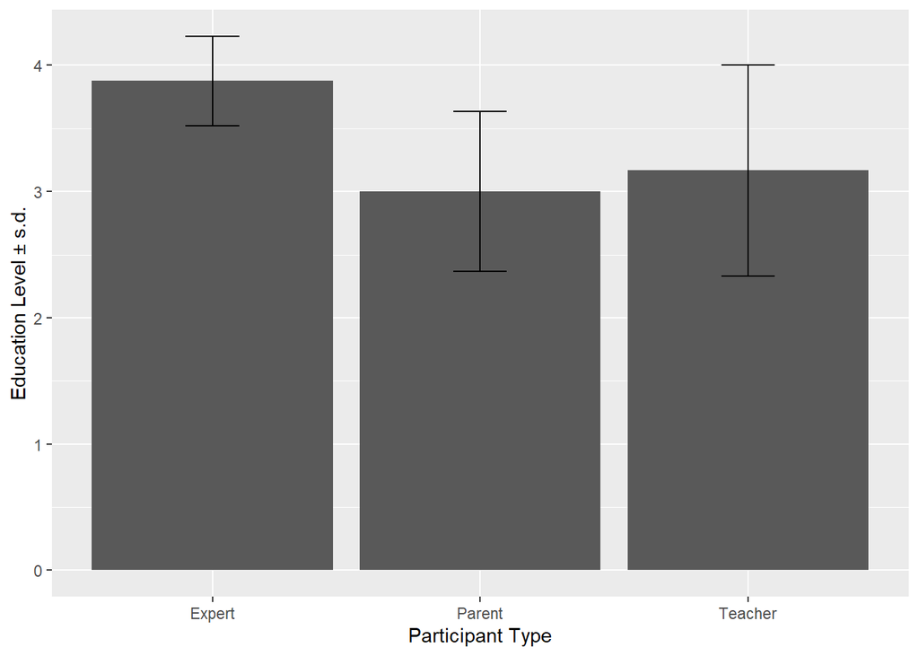

```
## # A tibble: 3 x 6
##   ParticipantType count  mean    sd   min   max
## * <fct>           <int> <dbl> <dbl> <dbl> <dbl>
## 1 Expert              8  3.88 0.354     3     4
## 2 Parent             11  3    0.632     2     4
## 3 Teacher            12  3.17 0.835     1     4
```

*One-way ANOVA results suggest significant group differences in education level by participant type.*

```
## Levene's Test for Homogeneity of Variance (center = median)
##       Df F value Pr(>F)
## group  2    1.12   0.34
##       28
```

```
##                 Df Sum Sq Mean Sq F value Pr(>F)
## ParticipantType  2   3.85   1.923    4.29  0.024 *
## Residuals       28  12.54   0.448
## ---
## Signif. codes:  0 '***' 0.001 '**' 0.01 '*' 0.05 '.' 0.1 ' ' 1
```

*Tukey post-hoc results suggest that parents have a lower average educational level than experts in the sample.*

```
##   Tukey multiple comparisons of means
##     95% family-wise confidence level
##
## Fit: aov(formula = Dem_Educ ~ ParticipantType, data = AoAData)
##
## $ParticipantType
##                   diff     lwr      upr  p adj
## Parent-Expert  -0.8750 -1.6445 -0.10552 0.0233
## Teacher-Expert -0.7083 -1.4642  0.04752 0.0695
## Teacher-Parent  0.1667 -0.5246  0.85792 0.8231
```

#### **Occupation**

Here are the reported occupations of participants:

```
##  [1] House wife
##  [2] ASLP
##  [3] Teacher
##  [4] teaching and consultation
##  [5] SPEECH LANGUAGE PATHOLOGIST
##  [6] AUDIOLOGIST AND SPEECH LANGUAGE PATHOLOGIST
##  [7] Audiologist
##  [8] House wife
##  [9] Associate Professor
## [10] ASST LECTURE
## [11] Teacher
## [12] teacher
## [13] TEACHER
## [14] Home Maker
## [15] Teacher
```

[output cut: 17 more lines]

#### **Language profile**

Below are reported languages spoken by participants:

```
##          Dem_Lang1          Dem_Lang2 Dem_Lang3 Dem_Lang4 Dem_Lang5
## 1             Tulu            Kannada     Hindi      <NA>      <NA>
## 2          KANNADA            ENGLISH     HINDI      <NA>      <NA>
## 3          Kannada              Hindi      <NA>      <NA>      <NA>
## 4          kannada            english     hindi     tamil      <NA>
## 5          KANNADA            ENGLISH      TULU     HINDI      <NA>
## 6          KANNADA               TULU MALAYALAM   ENGLISH     TAMIL
## 7          Kannada            English     Hindi      Tulu      <NA>
## 8          Kannada               Tulu   English     Hindi      <NA>
## 9          Kannada            English     Hindi      <NA>      <NA>
## 10         KONKANI            KANNADA   ENGLISH     HINDI      TULU
## 11         Kannada            Konkani     Hindi   English      <NA>
## 12            tulu            kannada      <NA>      <NA>      <NA>
## 13         KANNADA              HINDI   ENGLISH      <NA>      <NA>
## 14         Kannada            English      Tulu     Hindi     Tamil
```

[output cut: 17 more lines]

*Among languages listed are Kannada, Tulu, Konkani, English, Hindi, Malayalam, and Tamil.*

Two responses written in Kannada script say: Kannada ಕನ್ನಡ Telugu ತೆಲುಗುf

**How many languages do participants speak?**

Frequency counts of languages spoken by participants:

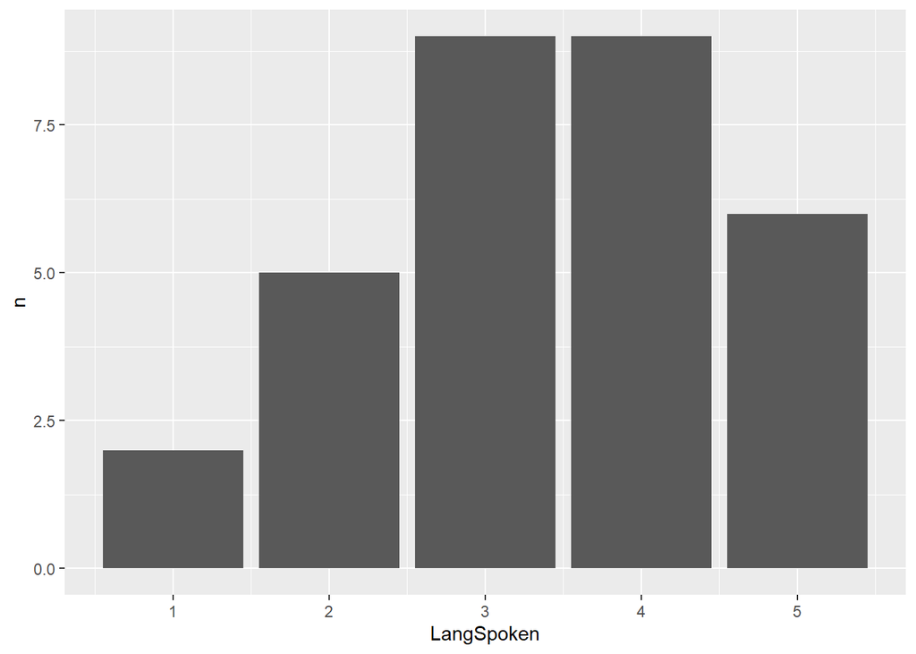

```
##   LangSpoken n
## 1          1 2
## 2          2 5
## 3          3 9
## 4          4 9
## 5          5 6
```

*Most participants speak 3 or more languages, with a mean of 3.3871 languages spoken.*

```
##   count  mean    sd min max
## 1    31 3.387 1.174   1   5
```

**Frequency of speaking each language:**

Participants generally listed languages in the order of frequency of speaking them. The first language listed is usually Kannada.

Value labels: 1 = Daily 2 = Several times a week 3 = Sometimes 4 = Never

```
##            N  mean     sd
## Dem_Lang1 31 1.000 0.0000
## Dem_Lang2 29 1.379 0.6219
## Dem_Lang3 24 2.292 0.9079
## Dem_Lang4 15 2.267 0.8837
## Dem_Lang5  6 2.667 1.0328
```

This is the average number of languages spoken by participant type:

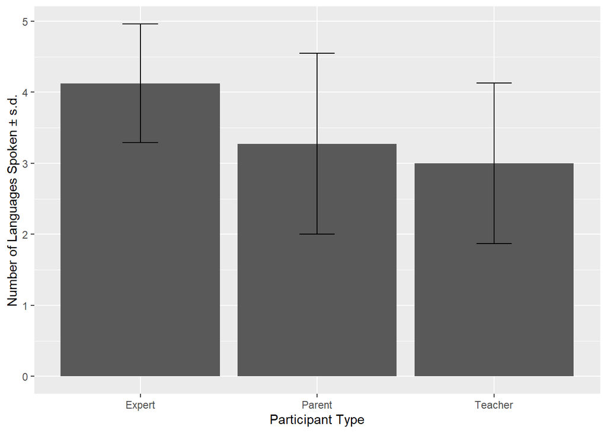

```
## # A tibble: 3 x 6
##   ParticipantType count  mean    sd   min   max
## * <fct>           <int> <dbl> <dbl> <dbl> <dbl>
## 1 Expert              8  4.12 0.835     3     5
## 2 Parent             11  3.27 1.27      1     5
## 3 Teacher            12  3    1.13      1     5
```

*One-way ANOVA results suggest no significant group differences in number of languages spoken by participant type:*

```
## Levene's Test for Homogeneity of Variance (center = median)
##       Df F value Pr(>F)
## group  2    0.67   0.52
##       28
```

```
##                 Df Sum Sq Mean Sq F value Pr(>F)
## ParticipantType  2    6.3    3.15    2.52  0.099 .
## Residuals       28   35.1    1.25
## ---
## Signif. codes:  0 '***' 0.001 '**' 0.01 '*' 0.05 '.' 0.1 ' ' 1
```

### THE WORD LIST

#### **Age of Acquisition Word List**

Here are properties of the word list for the age-of-acquisition survey:

```
## # A tibble: 5 x 2
##   POS           n
##   <chr>     <int>
## 1 Noun        400
## 2 Verb        275
## 3 Adjective    70
## 4 Adverb       70
## 5 Pronoun      70
```

**By number**

This is the distribution of POS by singular and plural forms:

No POS x number interaction effects will be computed due to the large asymmetry in the word list by number.

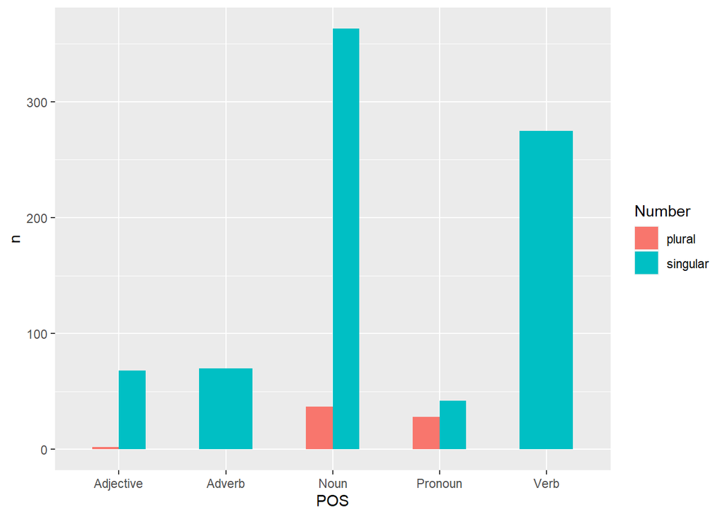

```
##           Number plural singular Sum
## POS
## Adjective             2       68  70
## Adverb                0       70  70
## Noun                 37      363 400
## Pronoun              28       42  70
## Verb                  0      275 275
## Sum                  67      818 885
```

**By inflection**

POS x inflection interaction effects will be computed with caution due to some small cell sizes.

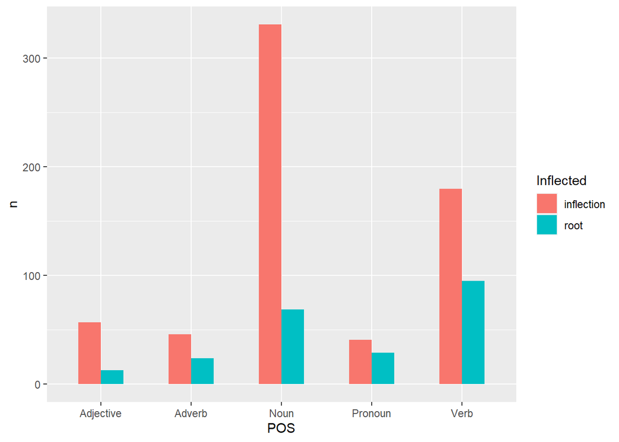

```
##           Inflected inflection root Sum
## POS
## Adjective                   57   13  70
## Adverb                      46   24  70
## Noun                       331   69 400
## Pronoun                     41   29  70
## Verb                       180   95 275
## Sum                        655  230 885
```

**By book level**

This is the distribution of POS by book level:

Levels 1 to 3 will be recoded to numerical values and words not in the sentence corpus will be excluded in later analysis.

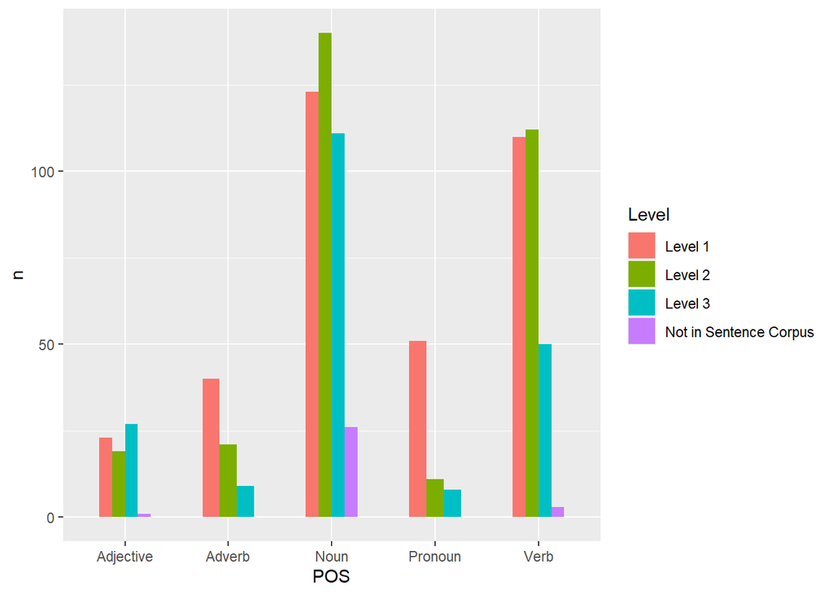

```
##           Level Level 1 Level 2 Level 3 Not in Sentence Corpus Sum
## POS
## Adjective            23      19      27                      1  70
## Adverb               40      21       9                      0  70
## Noun                123     140     111                     26 400
## Pronoun              51      11       8                      0  70
## Verb                110     112      50                      3 275
## Sum                 347     303     205                     30 885
```

**By occurrence in prior tests**

This is the distribution of POS by occurrence in prior tests:

POS x prior test interaction effects will not be computed due to the asymmetric distribution and some small cell sizes.

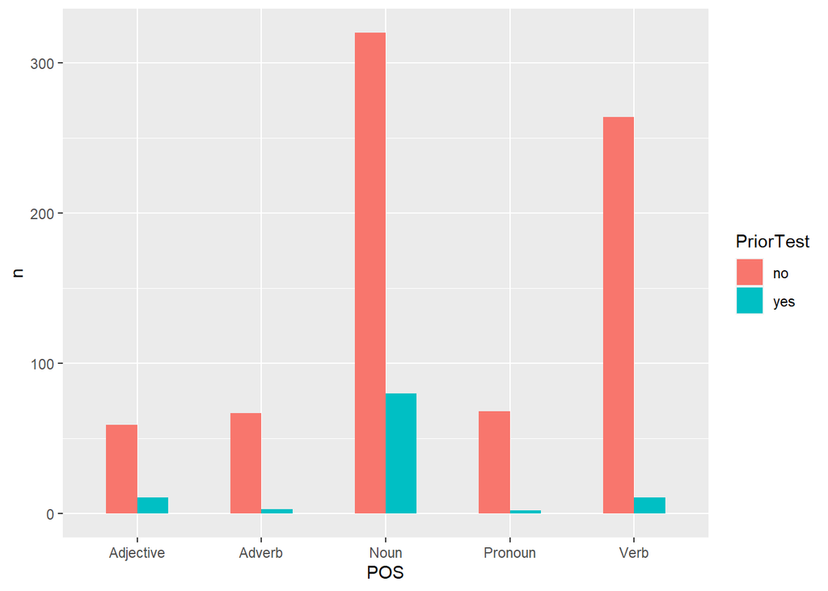

```
##           PriorTest  no yes Sum
## POS
## Adjective            59  11  70
## Adverb               67   3  70
## Noun                320  80 400
## Pronoun              68   2  70
## Verb                264  11 275
## Sum                 778 107 885
```

**By semantic category**

These are the semantic categories of nouns in the word list:

Nouns in the AoA list include various semantic categories, including *thing*, *animal*, *food*, *nature*, and *person*.

```
## # A tibble: 41 x 2
##    Type       n
##    <chr>  <int>
##  1 thing     84
##  2 animal    44
##  3 food      31
##  4 nature    29
##  5 person    25
##  6 time      21
##  7 body      20
##  8 family    19
##  9 place     17
## 10 act       12
## # ... with 31 more rows
```

#### **Visualisability Word List**

Here are properties of the word list for the visualisability survey:

```
## # A tibble: 2 x 2
##   POS       n
##   <chr> <int>
## 1 Noun    100
## 2 Verb     15
```

**By number**

This is the distribution of POS by number:

No analysis of visualisability ratings by number will be done due to the small number of plural words.

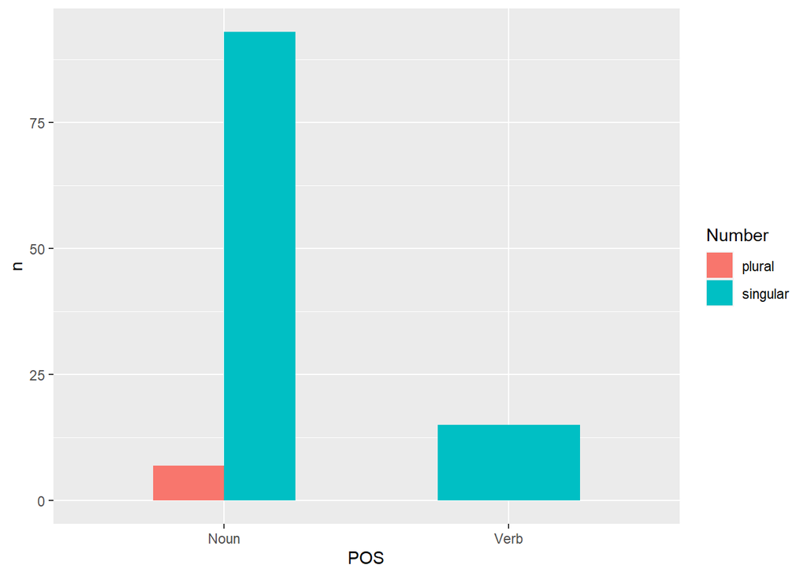

```
##      Number plural singular Sum
## POS
## Noun             7       93 100
## Verb             0       15  15
## Sum              7      108 115
```

**By inflection**

This is the distribution of POS by inflection:

No analysis of visualisability ratings by inflection will be done due to the large asymmetry in word distribution.

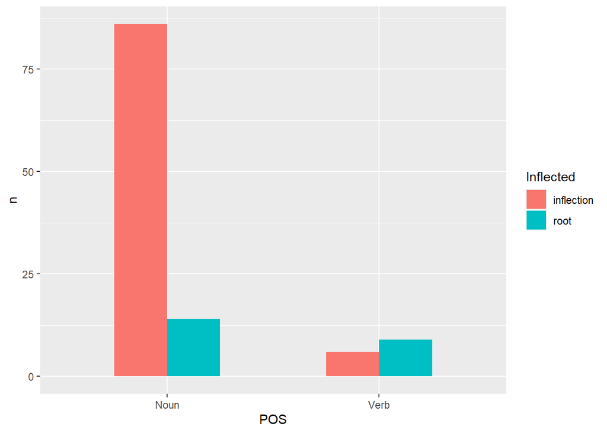

```
##      Inflected inflection root Sum
## POS
## Noun                   86   14 100
## Verb                    6    9  15
## Sum                    92   23 115
```

**By book level**

This is the distribution of POS by book level:

Further analysis will be based on recoded values with words not in sentence corpus recoded.

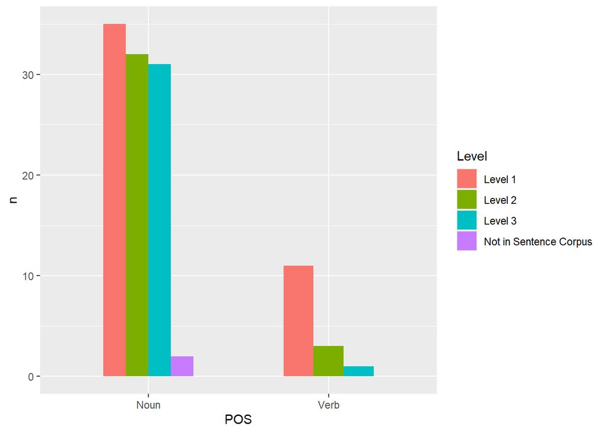

```
##      Level Level 1 Level 2 Level 3 Not in Sentence Corpus Sum
## POS
## Noun            35      32      31                      2 100
## Verb            11       3       1                      0  15
## Sum             46      35      32                      2 115
```

**By occurrence in prior tests**

This is the distribution of POS by occurrence in prior tests:

No analysis of visualisability ratings by prior test will be computed due to the large asymmetry in word distribution.

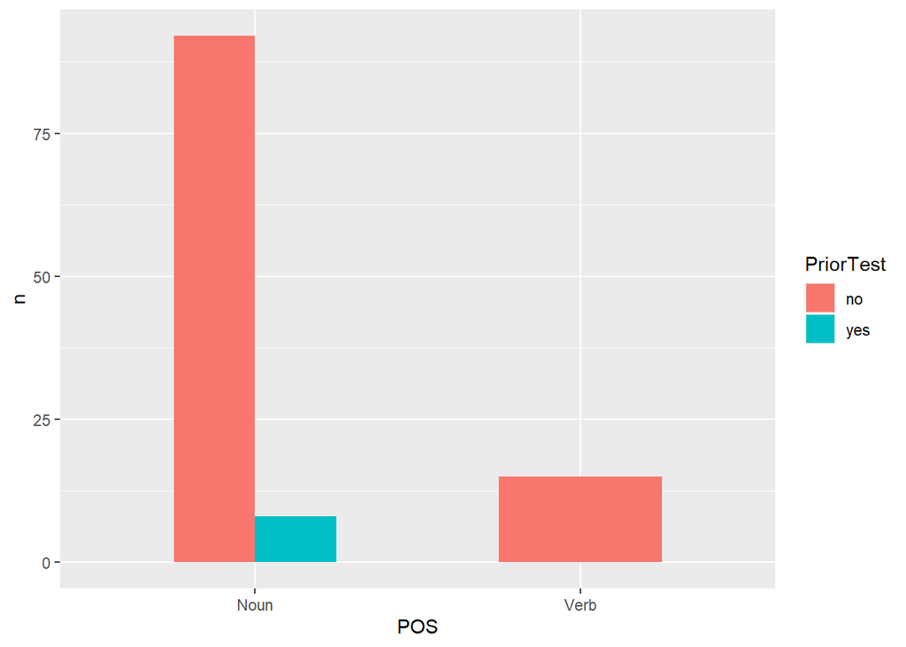

```
##      PriorTest  no yes Sum
## POS
## Noun            92   8 100
## Verb            15   0  15
## Sum            107   8 115
```

**By semantic category**

These are the semantic categories of nouns in the word list:

Nouns in the visualisability list include various semantic categories, including *thing*, *people*, *time*, and *animal*.

```
## # A tibble: 17 x 2
##    Type                   n
##    <chr>              <int>
##  1 thing                 34
##  2 person                15
##  3 time                  13
##  4 animal                10
##  5 place                  7
##  6 act                    4
##  7 facts and feelings     3
##  8 nature                 3
##  9 event                  2
## 10 state                  2
## 11 body                   1
## 12 Fact                   1
## 13 friendship             1
## 14 people                 1
## 15 quantity               1
## 16 Thought                1
## 17 uncountable            1
```

### “I DON’T KNOW” RESPONSES

#### *Age-of-acquisition ratings*

**By participant**

Here is a frequency count of ‘I don’t know’ responses to the 885-word age-of-acquisition survey by participant:

*One teacher participant has a relatively high number of “I don’t know” responses (16%)*

We will investigate this further by looking at interrater reliability measures.

```
##    Login   n ParticipantType
## 1     D6 141         Teacher
## 2     D1  20          Parent
## 3     M2  15          Expert
## 4     M6  12          Parent
## 5     D3  11          Parent
## 6     M9  11          Parent
## 7    M12  10          Parent
## 8    D18   9         Teacher
## 9     S1   9          Expert
## 10    M3   6          Expert
## 11    M7   4          Expert
## 12   S13   4          Parent
## 13   S15   4         Teacher
## 14    S2   4          Expert
## 15   D12   3         Teacher
## 16    D4   3         Teacher
## 17    D8   3         Teacher
## 18    M5   3         Teacher
## 19    M8   3          Parent
## 20    S3   3         Teacher
## 21    S8   3          Parent
## 22   D11   2         Teacher
## 23    S4   2         Teacher
## 24    S6   2         Teacher
## 25    S7   2          Parent
## 26    S9   2          Parent
## 27    M1   1          Expert
## 28   M13   1          Parent
```

**By word**

Here is a frequency count of “I don’t know” responses to the 885-word age-of-acquisition survey by word:

*A total of 199 out of 885 words received at least one “I don’t know” response.*

We will investigate this further by looking at the properties of the words that garner this response consistently across participants.

```
##     EnglishTranscription n       POS                                                       Meaning
## 1            anTekaayiyu 8      Noun                                                       soapnut
## 2        bairaagiyobbanu 6      Noun                                                        a monk
## 3                 biLicu 5      Verb                                                 Bleach, white
## 4                 caDiyu 5      Noun                                                          cane
## 5                kaakanu 5      Noun                                                         Uncle
## 6              kuncikeyu 5      Noun                                                         Brush
## 7       naaDiyalliDuttaa 5      Verb                             by keeping in blood vessel artery
## 8               nereyadu 5      Noun                                                     Neighbour
## 9               sigaDiyu 5      Noun                                                         prawn
## 10                uNNeyu 5      Noun                                                   sheep Wool
## 11              neeygeyu 4      Noun                                                         weave
## 12             neTTageyu 4      Noun                                               Straight, erect
## 13                samane 4    Adverb                                                         equal
## 14      yuddhakaaliinavu 4      Noun                                                       warlike
```

[output cut: 185 more lines]

**Frequency**

*Most words (77%) received an “I don’t know” response only once.*

```
##   freqIDK   n     pct
## 1       1 153 76.8844
## 2       2  26 13.0653
## 3       3   6  3.0151
## 4       4   4  2.0101
## 5       5   8  4.0201
## 6       6   1  0.5025
## 7       8   1  0.5025
```

**Frequency by POS**

In terms of absolute numbers, verbs and nouns received the most “I don’t know” responses. However, in terms of relative proportions by parts of speech, adjectives and adverbs had the highest percentage of these responses.

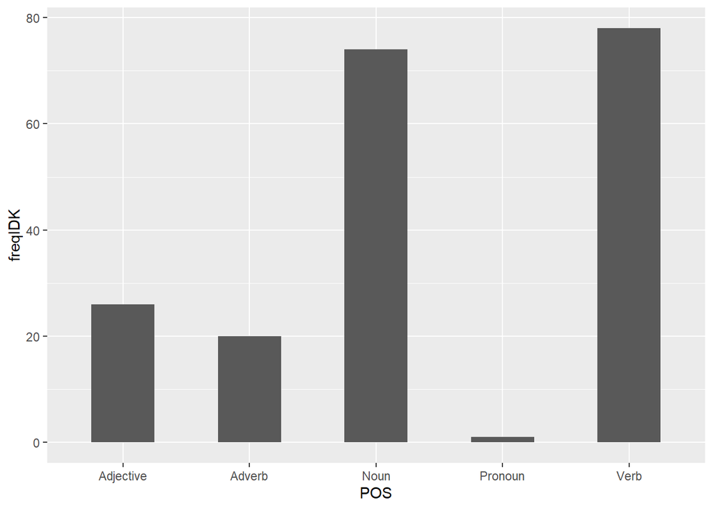

```
##         POS freqIDK nPOS pctPOS
## 1 Adjective      26   70 37.143
## 2    Adverb      20   70 28.571
## 3      Verb      78  275 28.364
## 4      Noun      74  400 18.500
## 5   Pronoun       1   70  1.429
```

#### **Visualisability ratings**

**By participant**

Here is a frequency count of “I don’t know” responses to the 115-word visualisability survey by participant:

The same teacher participant responded “I don’t know” to 13% of words. Interrater reliability measures will determine their inclusion in the final data set.

```
##    Login  n ParticipantType
## 1     D6 15         Teacher
## 2    S15 13         Teacher
## 3     M2  6          Expert
## 4     S1  5          Expert
## 5     M9  4          Parent
## 6     M3  2          Expert
## 7     S4  2         Teacher
## 8    D11  1         Teacher
## 9    D18  1         Teacher
## 10    M1  1          Expert
## 11   S13  1          Parent
## 12    S6  1         Teacher
```

**By word**

Here is a frequency count of ‘Don’t Know’ responses to the 115-word visualisability survey by word:

*A total of 33 out of 115 words received at least one “I don’t know” response.*

We will investigate this further by looking at the properties of the words that garner this response consistently across participants.

```
##    EnglishTranscription n  POS         Meaning
## 1             kuncikeyu 6 Noun           Brush
## 2                caDiyu 5 Noun            cane
## 3              nereyadu 3 Noun       Neighbour
## 4            caduruttaa 2 Verb      dispersing
## 5               cintisu 2 Verb           worry
## 6              gorakeyu 2 Noun           snore
## 7              kaNajavu 2 Noun            wasp
## 8              kShaNavu 2 Noun          moment
## 9               naaLeyu 2 Noun        Tomorrow
## 10            neTTageyu 2 Noun Straight, erect
## 11           vijnaaniyu 2 Noun       Scientist
## 12           bhuupaTavu 1 Noun             map
## 13               dinavu 1 Noun             Day
## 14              ganTeyu 1 Noun            hour
```

[output cut: 19 more lines]

**Frequency**

*Most words (67%) received this response only once.*

```
##   freqIDK  n   pct
## 1       1 22 66.67
## 2       2  8 24.24
## 3       3  1  3.03
## 4       5  1  3.03
## 5       6  1  3.03
```

### RATINGS BY PARTICIPANT CHARACTERISTICS

#### **Are there significant differences in AoA ratings by group?**

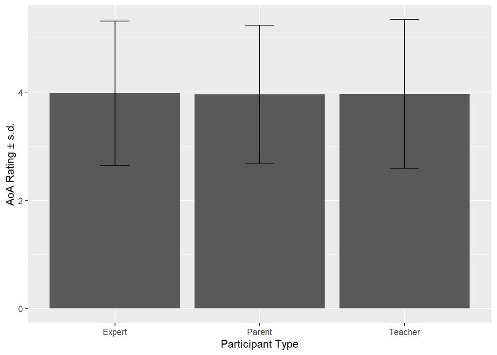

```
## # A tibble: 3 x 5
##   ParticipantType  mean    sd   min   max
## * <chr>           <dbl> <dbl> <dbl> <dbl>
## 1 Expert           3.98  1.33     1     6
## 2 Parent           3.95  1.28     1     6
## 3 Teacher          3.96  1.37     1     6
```

Value labels: 1 = 0-1, 2 = 2-3, 3 = 4-5, 4 = 6-7, 5 = 8-9, 6 = 10+ years old

*One-way ANOVA results suggest that there are no significant differences in AoA ratings by participant group.*

```
## Levene's Test for Homogeneity of Variance (center = median)
##          Df F value  Pr(>F)
## group     2    29.1 2.3e-13 ***
##       27139
## ---
## Signif. codes:  0 '***' 0.001 '**' 0.01 '*' 0.05 '.' 0.1 ' ' 1
```

```
##                    Df Sum Sq Mean Sq F value Pr(>F)
## ParticipantType     2      2    1.15    0.65   0.52
## Residuals       27139  48042    1.77
## 293 observations deleted due to missingness
```

#### **Are there significant differences in visualisability ratings by group?**

On average, participants rated the words as “very easy” or “ok” to visualise.

[figure not shown]

```
## # A tibble: 3 x 5
##   ParticipantType  mean    sd   min   max
## * <chr>           <dbl> <dbl> <dbl> <dbl>
## 1 Expert           1.78 1.00      1     4
## 2 Parent           1.80 0.934     1     4
## 3 Teacher          1.60 0.883     1     4
```

Value labels: 1 = Very easy, 2 = Ok, 3 = Difficult, 4 = Very difficult

*One-way ANOVA results suggest significant group differences in visualisability ratings by group.*

```
## Levene's Test for Homogeneity of Variance (center = median)
##         Df F value  Pr(>F)
## group    2    20.4 1.6e-09 ***
##       3510
## ---
## Signif. codes:  0 '***' 0.001 '**' 0.01 '*' 0.05 '.' 0.1 ' ' 1
```

```
##                   Df Sum Sq Mean Sq F value  Pr(>F)
## ParticipantType    2     29   14.57    16.8 5.7e-08 ***
## Residuals       3510   3052    0.87
## ---
## Signif. codes:  0 '***' 0.001 '**' 0.01 '*' 0.05 '.' 0.1 ' ' 1
## 52 observations deleted due to missingness
```

Post-hoc tests were conducted using the Games-Howell test due to a violation of the homogeneity assumption based on Levene’s test.

*Compared to parents and experts, teachers rated words as more visualisable on average.*

```
## # A tibble: 3 x 8
##   .y.       group1 group2  estimate conf.low conf.high       p.adj p.adj.signif
## * <chr>     <chr>  <chr>      <dbl>    <dbl>     <dbl>       <dbl> <chr>
## 1 VisRating Expert Parent    0.0195  -0.0799    0.119  0.89        ns
## 2 VisRating Expert Teacher  -0.175   -0.272    -0.0791 0.0000596   ****
## 3 VisRating Parent Teacher  -0.195   -0.278    -0.111  0.000000153 ****
```

#### **Is there a significant relationship between participant ratings and education levels?**

*The correlation between education level and AoA ratings is -0.08 and is significant at p < .001, indicating a small negative correlation such that participants with higher education levels tend to rate words as earlier-acquired than participants with lower education levels.*

```
##
##  Pearson's product-moment correlation
##
## data:  AoALong2$Dem_Educ and AoALong2$AoARating
## t = -13, df = 27140, p-value <2e-16
## alternative hypothesis: true correlation is not equal to 0
## 95 percent confidence interval:
##  -0.09185 -0.06821
## sample estimates:
##      cor
## -0.08004
```

*In contrast, there is no significant correlation between education level and visualisability ratings.*

```
##
##  Pearson's product-moment correlation
##
## data:  VisLong2$Dem_Educ and VisLong2$VisRating
## t = 0.039, df = 3511, p-value = 1
## alternative hypothesis: true correlation is not equal to 0
## 95 percent confidence interval:
##  -0.03241  0.03373
## sample estimates:
##       cor
## 0.0006619
```

### ITEM-LEVEL OBSERVATIONS

#### **Which words are relatively high and low in consensus in AoA ratings?**

Results are presented by part of speech.

#### **Nouns only**

**High-consensus words**

```
##   EnglishTranscription AoARating     SD  POS   Number          Inflected          Meaning
## 1     yuddhakaaliinavu     5.741 0.5257 Noun Singular         inflection          warlike
## 2      jnaanigaLellaru     5.633 0.6149 Noun   Plural complex inflection all the wise men
## 3           kalmashavu     5.607 0.6289 Noun Singular         inflection         impurity
## 4             dooShavu     5.500 0.6297 Noun Singular         inflection  Flaw, Deformity
## 5            jigupseyu     5.750 0.6455 Noun Singular         inflection       averseness
## 6          avashyakavu     5.367 0.6687 Noun Singular         inflection        necessity
```

**Low-consensus words**

```
##   EnglishTranscription AoARating    SD  POS   Number  Inflected                                   Meaning
## 1              kaakanu     3.885 1.532 Noun Singular inflection                                     Uncle
## 2            ceeShTeyu     4.355 1.496 Noun Singular inflection                               mischievous
## 3               nageyu     3.774 1.477 Noun Singular inflection                                  Laughter
## 4                maccu     4.200 1.400 Noun Singular       root                                       axe
## 5               haTavu     3.871 1.384 Noun Singular inflection                                 Obstinate
## 6                boTTu     3.194 1.376 Noun singular       root a circlet or a tilak mark on the forehead
```

Value labels: 1 = 0-1, 2 = 2-3, 3 = 4-5, 4 = 6-7, 5 = 8-9, 6 = 10+ years old

High-consensus nouns tend to be later-acquired (e.g., for 8- to 9-year-old children) and inflected compared to low-consensus nouns, which are earlier-acquired (e.g., for 4- to 5- and 6- to 7-year-old children) and more varied in root/inflected forms.

#### **Verbs only**

**High-consensus words**

```
##   EnglishTranscription AoARating     SD  POS   Number  Inflected      Meaning
## 1       uddeeshisuttaa     5.767 0.5040 Verb singular inflection   addressing
## 2             udgarisu     5.667 0.5467 Verb singular inflection      exclaim
## 3              carcisu     5.290 0.6925 Verb singular inflection      discuss
## 4        sthaapisuttaa     5.581 0.7199 Verb singular inflection establishing
## 5            satkarisu     5.433 0.7279 Verb singular inflection        honor
## 6                tiiru     5.286 0.7629 Verb singular       root    to finish
```

**Low-consensus words**

```
##   EnglishTranscription AoARating    SD  POS   Number  Inflected         Meaning
## 1            uNisuttaa     3.968 1.602 Verb singular inflection         Feeding
## 2           hasiyuttaa     4.032 1.560 Verb Singular inflection          hunger
## 3              savaari     4.323 1.536 Verb singular       root            Ride
## 4               kedaru     4.367 1.520 Verb singular       root         scatter
## 5               mugisu     3.194 1.470 Verb Singular inflection finish, destroy
## 6               gadaru     4.226 1.454 Verb singular       root           shout
```

Value labels: 1 = 0-1, 2 = 2-3, 3 = 4-5, 4 = 6-7, 5 = 8-9, 6 = 10+ years old

A similar trend is noted with verbs. High-consensus verbs tend to be later-acquired and inflected compared to low-consensus verbs, which are earlier-acquired (e.g., for 4- to 5- and 6- to 7-year-old children) and more varied in root/inflected forms.

#### **Adjectives only**

**High-consensus words**

```
##   EnglishTranscription AoARating     SD       POS   Number  Inflected              Meaning
## 1           aadarshavu     5.517 0.5745 Adjective singular inflection                Ideal
## 2               hasiru     2.645 0.7978 Adjective singular       root                Green
## 3                kempu     2.645 0.8386 Adjective singular       root                  red
## 4              saNNadu     2.806 0.8725 Adjective singular inflection Small, little, Short
## 5                mooju     5.100 0.8847 Adjective singular       root           Larky, Fun
## 6              loohavu     5.097 0.9076 Adjective singular inflection             Metallic
```

**Low-consensus words**

```
##   EnglishTranscription AoARating    SD       POS   Number  Inflected          Meaning
## 1                buudu     4.065 1.413 Adjective singular       root             grey
## 2               majavu     4.516 1.387 Adjective singular inflection        Lark, Fun
## 3          haTamaariyu     4.258 1.365 Adjective singular inflection         Stubburn
## 4               dhuuLu     3.452 1.338 Adjective singular       root             Dust
## 5                muddu     2.867 1.332 Adjective singular       root Namby-Pamby, Pet
## 6             priitiyu     3.903 1.326 Adjective singular inflection             love
```

Value labels: 1 = 0-1, 2 = 2-3, 3 = 4-5, 4 = 6-7, 5 = 8-9, 6 = 10+ years old

There is more variation among high-consensus and low-consensus adjectives in terms of mean age-of-acquisition ratings and word properties.

#### **Adverbs only**

**High-consensus words**

```
##   EnglishTranscription AoARating     SD    POS   Number  Inflected                   Meaning
## 1          tabbibbaagi     5.400 0.5632 Adverb singular inflection Distractedly, confusingly
## 2        kaTTuniTTaagi     5.419 0.6720 Adverb singular inflection                  Strictly
## 3             saalaagi     3.806 0.7492 Adverb singular inflection                  in a row
## 4            kaataradi     5.300 0.7497 Adverb singular inflection              with anxiety
## 5            pariNaama     5.097 0.8309 Adverb singular       root                    impact
## 6       bharavaseyinda     5.333 0.8442 Adverb singular inflection      with hope, assurance
```

Value labels: 1 = 0-1, 2 = 2-3, 3 = 4-5, 4 = 6-7, 5 = 8-9, 6 = 10+ years old

**Low-consensus words**

```
##   EnglishTranscription AoARating    SD    POS   Number  Inflected  Meaning
## 1             Changane     4.633 1.450 Adverb singular       root  quickly
## 2              purrane     4.133 1.432 Adverb singular       root suddenly
## 3                haage     3.613 1.383 Adverb singular       root     like
## 4                matte     3.516 1.363 Adverb singular       root    later
## 5           haagendare     4.484 1.338 Adverb singular inflection    if so
## 6             ThaTTane     4.387 1.308 Adverb singular       root Abruptly
```

Value labels: 1 = 0-1, 2 = 2-3, 3 = 4-5, 4 = 6-7, 5 = 8-9, 6 = 10+ years old

Meanwhile, adverbs follow a more similar pattern with nouns and verbs, such that high-consensus words tend to be later-acquired (e.g., for 8- to 9-year-old children) and inflected than low-consensus words which are earlier acquired (from 4- to 7-years old) and roots.

#### **Pronouns only**

**High-consensus words**

```
##   EnglishTranscription AoARating     SD     POS   Number  Inflected Meaning
## 1                namma     3.065 0.6800 Pronoun   Plural       root     Our
## 2                niinu     2.484 0.7244 Pronoun Singular       root     You
## 3                naavu     3.065 0.7273 Pronoun   Plural       root  We are
## 4               ninage     2.613 0.7606 Pronoun Singular       root For you
## 5              avugaLa     4.258 0.7732 Pronoun   Plural inflection   Their
## 6                nimma     3.258 0.7732 Pronoun   Plural       root    Your
```

Value labels: 1 = 0-1, 2 = 2-3, 3 = 4-5, 4 = 6-7, 5 = 8-9, 6 = 10+ years old

**Low-consensus words**

```
##   EnglishTranscription AoARating    SD     POS   Number          Inflected     Meaning
## 1             naaneeke     4.226 1.203 Pronoun Singular         inflection   why am I?
## 2             mattondu     3.677 1.194 Pronoun Singular         inflection     Another
## 3               naanuu     2.935 1.153 Pronoun Singular         inflection      even I
## 4         avugaLondige     4.710 1.131 Pronoun   Plural complex inflection   With them
## 5            adaroLage     3.645 1.082 Pronoun Singular         inflection inside that
## 6           nanagantuu     4.355 1.082 Pronoun Singular         inflection  even to me
```

Value labels: 1 = 0-1, 2 = 2-3, 3 = 4-5, 4 = 6-7, 5 = 8-9, 6 = 10+ years old

High-consensus pronouns vary in age-of-acquisition ratings, ranging from 2 to 7 years old, are varied in terms of number, but are more likely to be roots. Low-consensus pronouns have a similar range of AoA ratings, but have a larger tendency to be singular and inflected.

#### **Which words are relatively high and low in consensus in visualisability ratings?**

#### **Nouns only**

**High-consensus words**

```
##   EnglishTranscription VisRating     SD  POS   Number  Inflected Meaning
## 1                cenDu     1.032 0.1796 Noun Singular       root    Ball
## 2               taleyu     1.097 0.3005 Noun singular inflection    head
## 3          gaDiyaaravu     1.129 0.3408 Noun Singular inflection   Clock
## 4              gombeyu     1.129 0.3408 Noun Singular inflection    doll
## 5          gaaLipaTavu     1.161 0.3739 Noun Singular inflection    Kite
## 6            iruvegaLu     1.161 0.3739 Noun   plural inflection    Ants
```

**Low-consensus words**

```
##   EnglishTranscription VisRating    SD  POS   Number  Inflected   Meaning
## 1            kuncikeyu     2.720 1.208 Noun Singular inflection     Brush
## 2               nijavu     2.633 1.189 Noun Singular inflection     Truth
## 3             varShavu     2.633 1.189 Noun Singular inflection      year
## 4              naaLeyu     2.448 1.183 Noun Singular inflection  Tomorrow
## 5             kShaNavu     3.034 1.180 Noun Singular inflection    moment
## 6              ninneyu     2.581 1.148 Noun Singular inflection Yesterday
```

High-consensus nouns for visualisability are rated “very easy” to visualise, whereas low-consensus nouns are rater “ok” or “difficult”. These tend to be inflected forms.

Value labels: 1 = Very easy, 2 = Ok, 3 = Difficult, 4 = Very difficult

#### **Verbs only**

**High-consensus words**

```
##   EnglishTranscription VisRating     SD  POS   Number  Inflected    Meaning
## 1                tinnu     1.323 0.6525 Verb Singular       Root        eat
## 2              nillisu     1.613 0.7154 Verb Singular inflection park, stop
## 3                muTTu     1.548 0.7229 Verb Singular       Root   touching
## 4                tumbu     1.774 0.8046 Verb Singular       Root    filling
## 5                nidde     1.548 0.8500 Verb Singular       Root      sleep
## 6           caduruttaa     2.690 0.8906 Verb Singular inflection dispersing
```

**Low-consensus words**

```
##   EnglishTranscription VisRating    SD  POS   Number  Inflected         Meaning
## 1               mugisu     2.323 1.166 Verb Singular inflection finish, destroy
## 2                nambu     2.871 1.147 Verb Singular       Root         believe
## 3                sustu     2.161 1.098 Verb Singular       Root          tiring
## 4                heeLu     2.100 1.094 Verb Singular       Root             say
## 5            tidduttaa     2.323 1.045 Verb Singular inflection      correcting
## 6                uLisu     2.452 1.028 Verb Singular inflection          remain
```

High-consensus verbs for visualisability are generally rated “very easy” to visualise, whereas low-consensus nouns tend to be rated as “ok”. These are varied between root and inflected forms.

Value labels: 1 = Very easy, 2 = Ok, 3 = Difficult, 4 = Very difficult

### RATINGS BY WORD CHARACTERISTICS

#### **Are there significant differences in AoA ratings by parts of speech?**

On average, nouns and pronouns are rated as first understood by children at 4- to 5-years-old; whereas, adjectives, adverbs, and verbs are rated as acquired at 6- to 7-years-old.

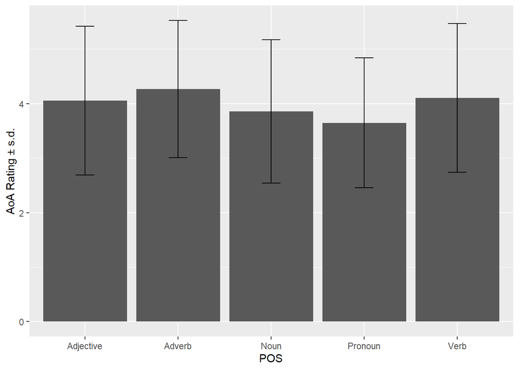

```
## # A tibble: 5 x 5
##   POS        mean    sd   min   max
## * <chr>     <dbl> <dbl> <dbl> <dbl>
## 1 Adjective  4.06  1.36     1     6
## 2 Adverb     4.27  1.26     1     6
## 3 Noun       3.85  1.31     1     6
## 4 Pronoun    3.65  1.19     1     6
## 5 Verb       4.10  1.36     1     6
```

Value labels: 1 = 0-1, 2 = 2-3, 3 = 4-5, 4 = 6-7, 5 = 8-9, 6 = 10+ years old

*One-way ANOVA results suggest that there are significant differences in AoA ratings by parts of speech.*

```
## Levene's Test for Homogeneity of Variance (center = median)
##          Df F value Pr(>F)
## group     4    21.9 <2e-16 ***
##       27137
## ---
## Signif. codes:  0 '***' 0.001 '**' 0.01 '*' 0.05 '.' 0.1 ' ' 1
```

```
##                Df Sum Sq Mean Sq F value Pr(>F)
## POS             4    740   185.0     106 <2e-16 ***
## Residuals   27137  47304     1.7
## ---
## Signif. codes:  0 '***' 0.001 '**' 0.01 '*' 0.05 '.' 0.1 ' ' 1
## 293 observations deleted due to missingness
```

Post-hoc tests were conducted using the Games-Howell test due to a violation of the homogeneity assumption based on Levene’s test.

```
## # A tibble: 10 x 8
##    .y.       group1    group2  estimate conf.low conf.high    p.adj p.adj.signif
##  * <chr>     <chr>     <chr>      <dbl>    <dbl>     <dbl>    <dbl> <chr>
##  1 AoARating Adjective Adverb    0.208    0.0988    0.318  2.20e- 6 ****
##  2 AoARating Adjective Noun     -0.202   -0.289    -0.116  6.83e-10 ****
##  3 AoARating Adjective Pronoun  -0.410   -0.516    -0.303  3.67e- 8 ****
##  4 AoARating Adjective Verb      0.0459  -0.0443    0.136  6.35e- 1 ns
##  5 AoARating Adverb    Noun     -0.411   -0.492    -0.330  0.       ****
##  6 AoARating Adverb    Pronoun  -0.618   -0.720    -0.516  4.00e- 8 ****
##  7 AoARating Adverb    Verb     -0.162   -0.247    -0.0778 1.69e- 6 ****
##  8 AoARating Noun      Pronoun  -0.207   -0.284    -0.130  0.       ****
##  9 AoARating Noun      Verb      0.248    0.196     0.300  3.40e- 8 ****
## 10 AoARating Pronoun   Verb      0.456    0.375     0.536  1.24e- 8 ****
```

*In summary, on average:*

1. Adverbs were rated as later-acquired than nouns, verbs, adjectives, and pronouns.
2. Adjectives were rated as later-acquired than nouns and pronouns.
3. Verbs were rated as later-acquired than nouns and pronouns.
4. Nouns were generally rated as earlier-acquired than other POS; however, nouns were generally rated as later-acquired than pronouns.

#### **Are there significant differences in visualisability ratings by parts of speech?**

*On average, nouns are rated as ‘very easy’ to visualise; verbs are rated as ‘ok’.*

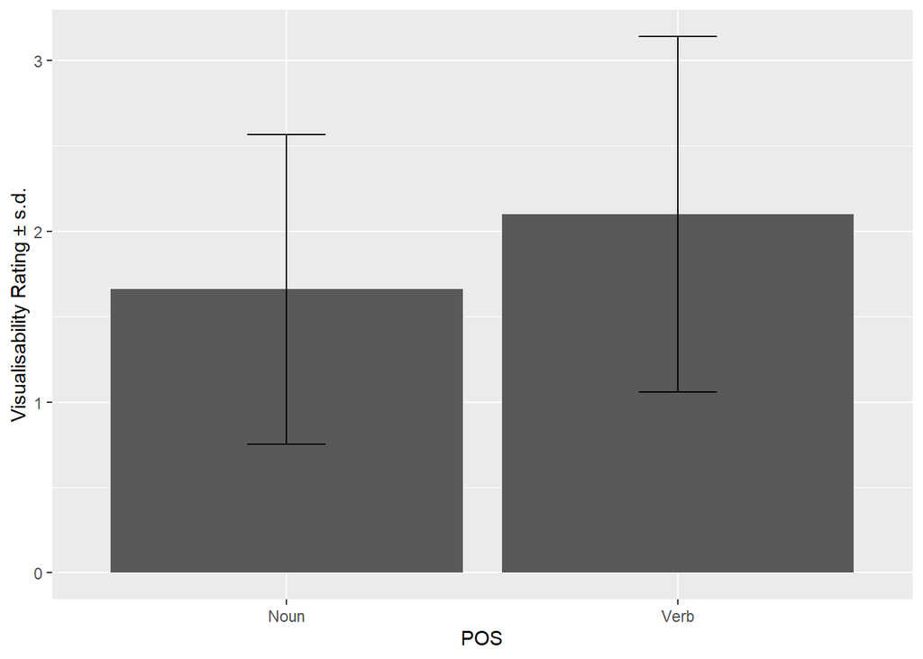

Value labels: 1 = Very easy, 2 = Ok, 3 = Difficult, 4 = Very difficult

A Welch’s t-test was conducted due to a violation of the homogeneity assumption based on Levene’s test.

```
## Levene's Test for Homogeneity of Variance (center = median)
##         Df F value  Pr(>F)
## group    1    16.2 5.9e-05 ***
##       3511
## ---
## Signif. codes:  0 '***' 0.001 '**' 0.01 '*' 0.05 '.' 0.1 ' ' 1
```

```
##
##  Welch Two Sample t-test
##
## data:  VisRating by POS
## t = -8.6, df = 567, p-value <2e-16
## alternative hypothesis: true difference in means is not equal to 0
## 95 percent confidence interval:
##  -0.5404 -0.3391
## sample estimates:
## mean in group Noun mean in group Verb
##               1.66               2.10
```

*On average, nouns are rated as easier to visualise than verbs.*

```
## # A tibble: 1 x 8
##   .y.       group1 group2 estimate conf.low conf.high    p.adj p.adj.signif
## * <chr>     <chr>  <chr>     <dbl>    <dbl>     <dbl>    <dbl> <chr>
## 1 VisRating Noun   Verb      0.440    0.339     0.540 4.87e-10 ****
```

#### **Is there a significant relationship between word length measures and AoA ratings?**

On average, words rated for AoA had 3.4321 syllables and 7.3552 phonemes.

Here are the average number of syllables by POS:

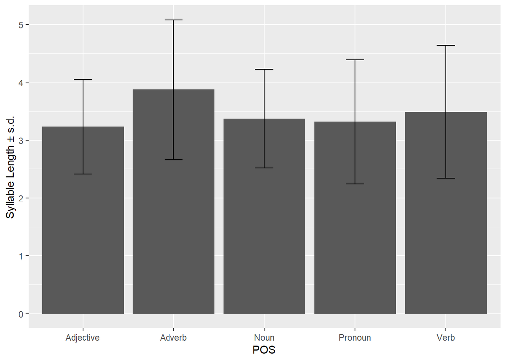

```
## # A tibble: 5 x 5
##   POS        mean    sd   min   max
## * <chr>     <dbl> <dbl> <dbl> <dbl>
## 1 Adjective  3.23 0.820     2     6
## 2 Adverb     3.87 1.20      2     6
## 3 Noun       3.37 0.855     1     7
## 4 Pronoun    3.31 1.07      2     6
## 5 Verb       3.49 1.15      2     8
```

Here are the average number of phonemes by POS:

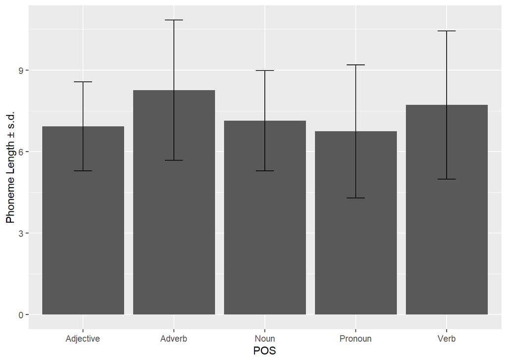

```
## # A tibble: 5 x 5
##   POS        mean    sd   min   max
## * <chr>     <dbl> <dbl> <dbl> <dbl>
## 1 Adjective  6.93  1.64     4    12
## 2 Adverb     8.26  2.58     4    14
## 3 Noun       7.14  1.84     2    15
## 4 Pronoun    6.74  2.45     3    13
## 5 Verb       7.71  2.72     3    18
```

*The correlation between syllable length and AoA ratings is 0.273 and is significant at p < .001, indicating a small positive correlation such that words with more syllables are rated as later-acquired than words with fewer syllables.*

```
##
##  Pearson's product-moment correlation
##
## data:  AoALong2$AoARating and AoALong2$SyllLength
## t = 47, df = 27109, p-value <2e-16
## alternative hypothesis: true correlation is not equal to 0
## 95 percent confidence interval:
##  0.262 0.284
## sample estimates:
##   cor
## 0.273
```

*The correlation between phoneme length and AoA ratings is 0.2808 and is significant at p < .001, indicating a small positive correlation such that words with more phonemes are rated as later-acquired than words with fewer phonemes.*

```
##
##  Pearson's product-moment correlation
##
## data:  AoALong2$AoARating and AoALong2$PhonLength
## t = 48, df = 27109, p-value <2e-16
## alternative hypothesis: true correlation is not equal to 0
## 95 percent confidence interval:
##  0.2698 0.2918
## sample estimates:
##    cor
## 0.2808
```

#### **Is there a significant relationship between word length measures and visualisability ratings?**

On average, words rated for visualisability had 3.313 syllables and 7.0435 phonemes.

Here are the average number of syllables by POS:

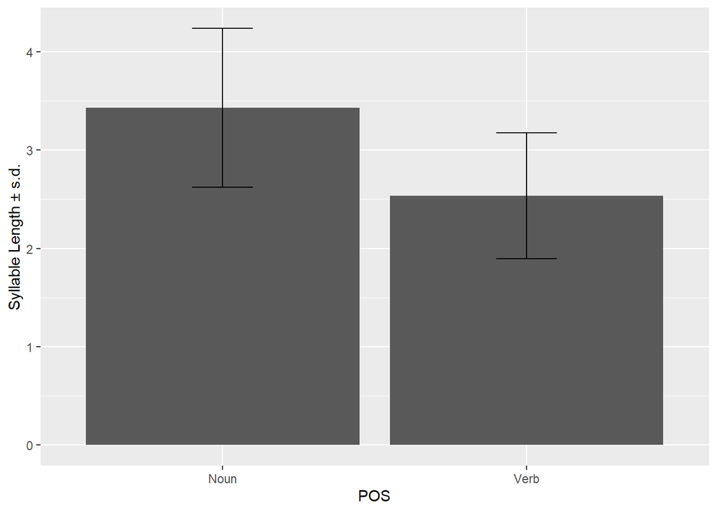

```
## # A tibble: 2 x 5
##   POS    mean    sd   min   max
## * <chr> <dbl> <dbl> <dbl> <dbl>
## 1 Noun   3.43 0.807     2     6
## 2 Verb   2.53 0.640     2     4
```

Here are the average number of phonemes by POS:

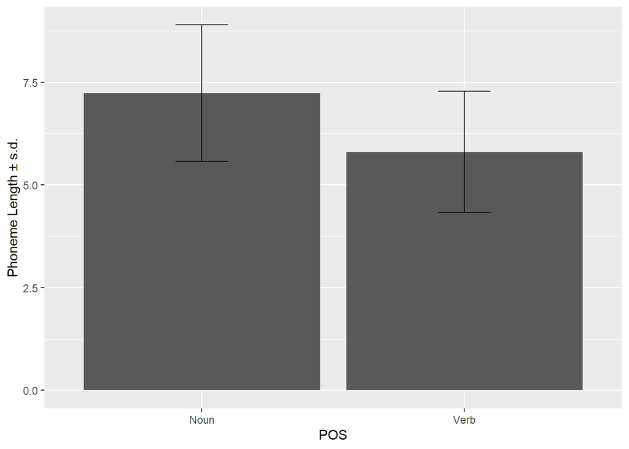

```
## # A tibble: 2 x 5
##   POS    mean    sd   min   max
## * <chr> <dbl> <dbl> <dbl> <dbl>
## 1 Noun   7.23  1.66     4    12
## 2 Verb   5.8   1.47     4     9
```

Results are presented separately for nouns (n = 100) and verbs (n = 15) due to the large asymmetry in word count.

**Nouns**

*There is no significant correlation between syllable length and visualisability ratings for nouns.*

```
##
##  Pearson's product-moment correlation
##
## data:  VisLengthCorrel_Nouns$VisRating and VisLengthCorrel_Nouns$SyllLength
## t = 1.5, df = 3052, p-value = 0.1
## alternative hypothesis: true correlation is not equal to 0
## 95 percent confidence interval:
##  -0.008483  0.062403
## sample estimates:
##     cor
## 0.02699
```

*The correlation between phoneme length and visualisability ratings for nouns is significant at p < .001; however the magnitude is very small: 0.0677.*

```
##
##  Pearson's product-moment correlation
##
## data:  VisLengthCorrel_Nouns$VisRating and VisLengthCorrel_Nouns$PhonLength
## t = 3.8, df = 3052, p-value = 2e-04
## alternative hypothesis: true correlation is not equal to 0
## 95 percent confidence interval:
##  0.03234 0.10296
## sample estimates:
##     cor
## 0.06774
```

**Verbs**

```
##
##  Pearson's product-moment correlation
##
## data:  VisLengthCorrel_Verbs$VisRating and VisLengthCorrel_Verbs$SyllLength
## t = 4.5, df = 457, p-value = 7e-06
## alternative hypothesis: true correlation is not equal to 0
## 95 percent confidence interval:
##  0.1186 0.2938
## sample estimates:
##    cor
## 0.2079
```

```
##
##  Pearson's product-moment correlation
##
## data:  VisLengthCorrel_Verbs$VisRating and VisLengthCorrel_Verbs$PhonLength
## t = 3.2, df = 457, p-value = 0.001
## alternative hypothesis: true correlation is not equal to 0
## 95 percent confidence interval:
##  0.05909 0.23807
## sample estimates:
##    cor
## 0.1498
```

*The correlation between phoneme length and visualisability ratings for verbs is 0.1498 and is significant at p < .01, indicating a small positive relationship such that verbs with more phonemes are rated as harder to visualise than verbs with fewer phonemes.*

#### **Is there a significant relationship between AoA ratings and book level?**

```
##
##  Pearson's product-moment correlation
##
## data:  AoALong2$AoARating and AoALong2$Level
## t = 30, df = 26242, p-value <2e-16
## alternative hypothesis: true correlation is not equal to 0
## 95 percent confidence interval:
##  0.1724 0.1958
## sample estimates:
##    cor
## 0.1841
```

*The correlation between book level and AoA ratings is 0.1841 and is significant at p < .001, indicating a small positive correlation such that words from higher-level books are rated as later-acquired than words from lower-level books.*

#### **Is there a significant relationship between visualisability ratings and book level?**

```
##
##  Pearson's product-moment correlation
##
## data:  VisLong2$VisRating and VisLong2$Level
## t = -3, df = 3449, p-value = 0.002
## alternative hypothesis: true correlation is not equal to 0
## 95 percent confidence interval:
##  -0.08484 -0.01829
## sample estimates:
##      cor
## -0.05162
```

*The correlation between book level and visualisability ratings is significant at p < .01; however the magnitude is very small: -0.0516.*

#### **Are there significant differences in AoA ratings between singular and plural words?**

On average, words are rated as first understood by children at 4- to 5-years-old regardless of whether the word is singular or plural.

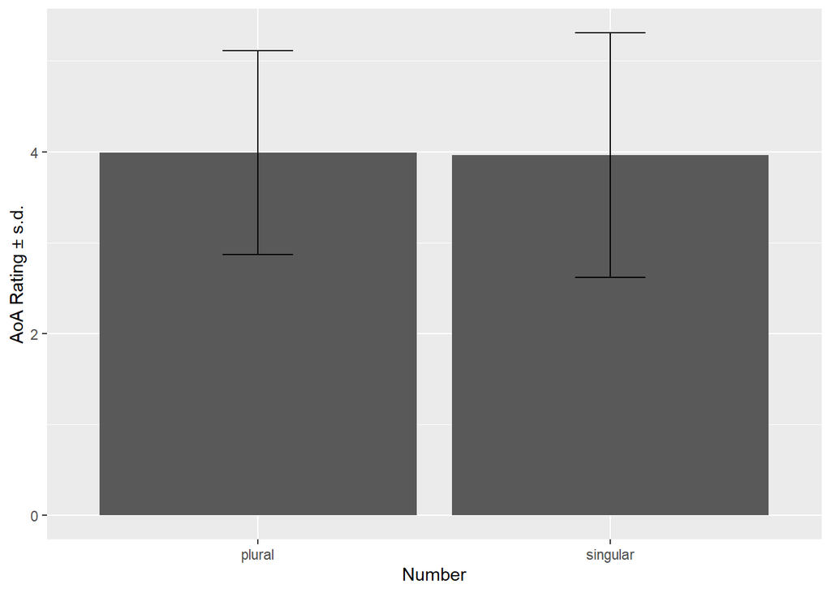

```
## # A tibble: 2 x 5
##   Number    mean    sd   min   max
## * <chr>    <dbl> <dbl> <dbl> <dbl>
## 1 plural    3.99  1.12     1     6
## 2 singular  3.96  1.35     1     6
```

Value labels: 1 = 0-1, 2 = 2-3, 3 = 4-5, 4 = 6-7, 5 = 8-9, 6 = 10+ years old

*T-test results suggest that there are no significant differences in AoA ratings by number.*

```
## Levene's Test for Homogeneity of Variance (center = median)
##          Df F value Pr(>F)
## group     1     200 <2e-16 ***
##       27140
## ---
## Signif. codes:  0 '***' 0.001 '**' 0.01 '*' 0.05 '.' 0.1 ' ' 1
```

```
##
##  Welch Two Sample t-test
##
## data:  AoARating by Number
## t = 1.1, df = 2584, p-value = 0.3
## alternative hypothesis: true difference in means is not equal to 0
## 95 percent confidence interval:
##  -0.02216  0.08018
## sample estimates:
##   mean in group plural mean in group singular
##                  3.990                  3.961
```

No POS x number interaction effects will be computed due to the large asymmetry in the word list by number.

No equivalent analysis was conducted for visualisability ratings due to low cell sizes.

#### **Are there significant differences in AoA ratings between root and inflected words?**

On average, root words are rated as first understood by children at 4- to 5-years-old; inflected words are rated as acquired at around 6- to 7-years-old.

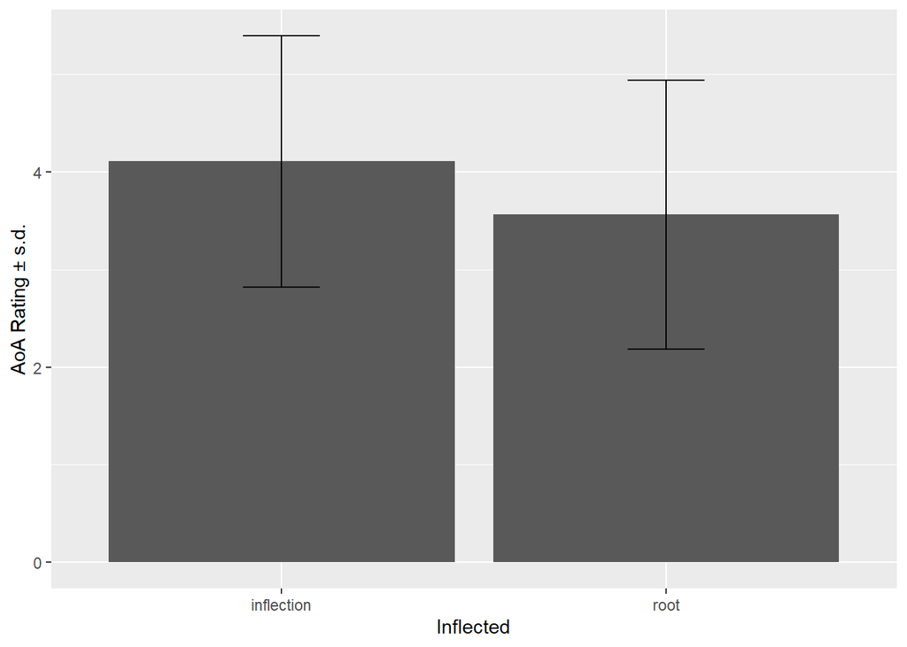

```
## # A tibble: 2 x 5
##   Inflected   mean    sd   min   max
## * <chr>      <dbl> <dbl> <dbl> <dbl>
## 1 inflection  4.11  1.28     1     6
## 2 root        3.56  1.37     1     6
```

Value labels: 1 = 0-1, 2 = 2-3, 3 = 4-5, 4 = 6-7, 5 = 8-9, 6 = 10+ years old

A Welch’s test was conducted due to a violation of the homogeneity assumption based on Levene’s test.

*On average, inflected words are rated as later-acquired than root words.*

```
## Levene's Test for Homogeneity of Variance (center = median)
##          Df F value Pr(>F)
## group     1     109 <2e-16 ***
##       27140
## ---
## Signif. codes:  0 '***' 0.001 '**' 0.01 '*' 0.05 '.' 0.1 ' ' 1
```

```
##
##  Welch Two Sample t-test
##
## data:  AoARating by Inflected
## t = 29, df = 11737, p-value <2e-16
## alternative hypothesis: true difference in means is not equal to 0
## 95 percent confidence interval:
##  0.5087 0.5820
## sample estimates:
## mean in group inflection       mean in group root
##                    4.106                    3.560
```

#### **Is there a significant Inflected x POS interaction in AoA ratings?**

No parametric testing will be done for now due to non-normal data distributions and highly unequal cell sizes.

*However, descriptive trends suggest a larger discrepancy in AoA ratings for nouns and pronouns, such that inflected forms are rated as later-acquired than root forms.*

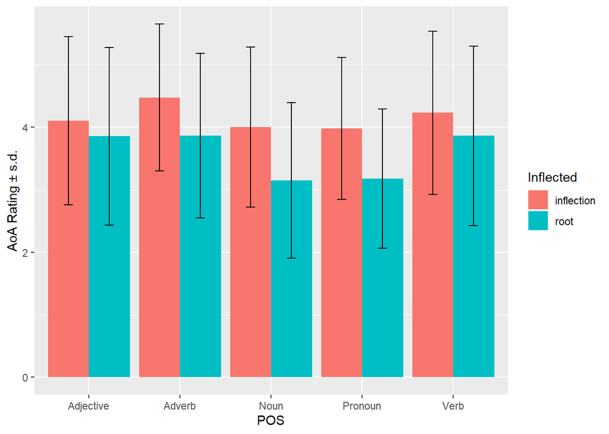

```
## # A tibble: 10 x 4
## # Groups:   POS [5]
##    POS       Inflected   mean    sd
##    <chr>     <chr>      <dbl> <dbl>
##  1 Adjective inflection  4.10  1.35
##  2 Adjective root        3.86  1.42
##  3 Adverb    inflection  4.47  1.18
##  4 Adverb    root        3.87  1.32
##  5 Noun      inflection  4.00  1.28
##  6 Noun      root        3.15  1.24
##  7 Pronoun   inflection  3.98  1.14
##  8 Pronoun   root        3.18  1.11
##  9 Verb      inflection  4.23  1.31
## 10 Verb      root        3.86  1.44
```

#### **Are there significant differences in visualisability ratings between root and inflected words?**

On average, both root and inflected words are rated as “very easy” to visualise.

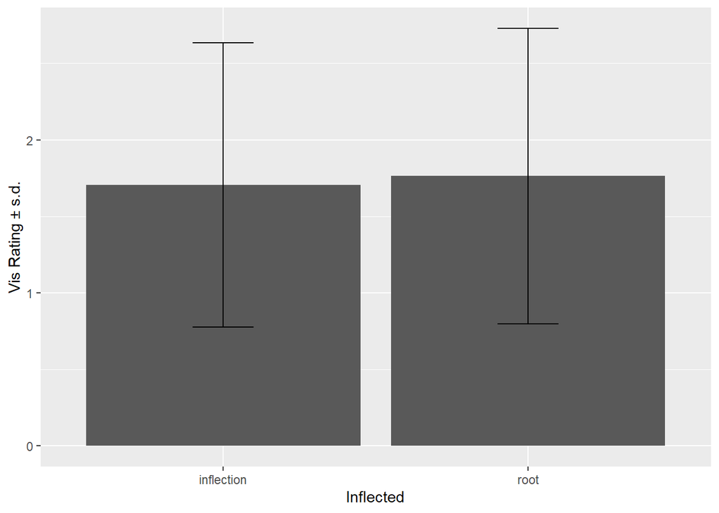

```
## # A tibble: 2 x 5
##   Inflected   mean    sd   min   max
## * <chr>      <dbl> <dbl> <dbl> <dbl>
## 1 inflection  1.71 0.929     1     4
## 2 root        1.76 0.965     1     4
```

Value labels: 1 = Very easy, 2 = Ok, 3 = Difficult, 4 = Very difficult

*T-test results suggest that there are no differences in visualisability ratings by inflection status.*

```
## Levene's Test for Homogeneity of Variance (center = median)
##         Df F value Pr(>F)
## group    1    2.06   0.15
##       3511
```

```
##
##  Welch Two Sample t-test
##
## data:  VisRating by Inflected
## t = -1.4, df = 1056, p-value = 0.2
## alternative hypothesis: true difference in means is not equal to 0
## 95 percent confidence interval:
##  -0.13574  0.02261
## sample estimates:
## mean in group inflection       mean in group root
##                    1.707                    1.763
```

#### **Are there significant differences in AoA ratings between words from prior tests and words taken only from the print corpus?**

On average, words from the corpus are rated as first understood by children at 4- to 5-years-old; whereas, words from prior tests are rated as acquired at 6- to 7-years-old.

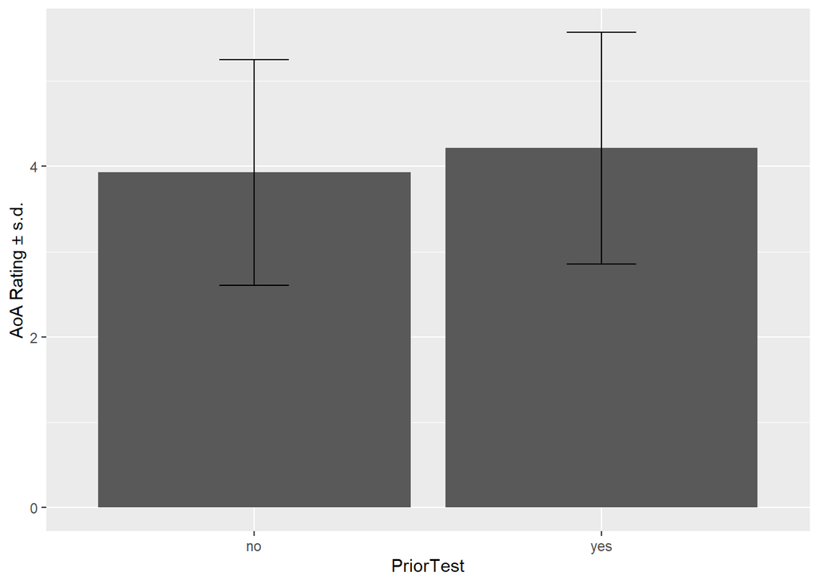

```
## # A tibble: 2 x 5
##   PriorTest  mean    sd   min   max
## * <chr>     <dbl> <dbl> <dbl> <dbl>
## 1 no         3.93  1.32     1     6
## 2 yes        4.21  1.36     1     6
```

Value labels: 1 = 0-1, 2 = 2-3, 3 = 4-5, 4 = 6-7, 5 = 8-9, 6 = 10+ years old

A Welch’s test was conducted due to a violation of the homogeneity assumption based on Levene’s test.

*On average, words from prior tests are rated as later-acquired than words taken only from the print corpus.*

No equivalent analysis was conducted for visualisability ratings due to low cell sizes.

```
## Levene's Test for Homogeneity of Variance (center = median)
##          Df F value  Pr(>F)
## group     1    16.9 3.8e-05 ***
##       27140
## ---
## Signif. codes:  0 '***' 0.001 '**' 0.01 '*' 0.05 '.' 0.1 ' ' 1
```

```
##
##  Welch Two Sample t-test
##
## data:  AoARating by PriorTest
## t = -11, df = 4151, p-value <2e-16
## alternative hypothesis: true difference in means is not equal to 0
## 95 percent confidence interval:
##  -0.335 -0.236
## sample estimates:
##  mean in group no mean in group yes
##             3.929             4.215
```

#### **Is there a significant Prior Test x POS interaction in AoA ratings?**

No parametric testing will be done for now due to non-normal data distributions and highly unequal cell sizes.

*However, descriptive trends suggest a larger discrepancy in AoA ratings for nouns and pronouns, such that items from prior tests are rated as later-acquired than those taken only from the word corpus.*

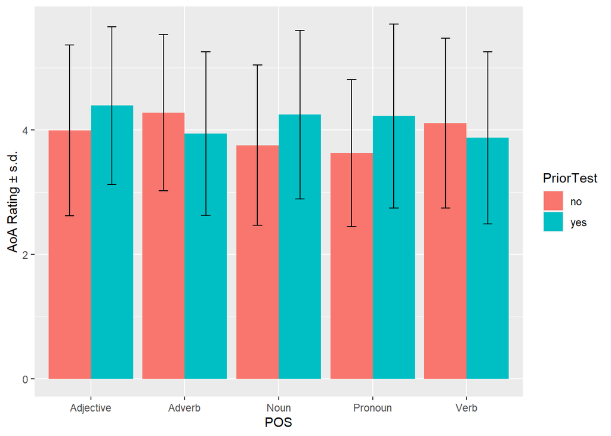

```
## # A tibble: 10 x 4
## # Groups:   POS [5]
##    POS       PriorTest  mean    sd
##    <chr>     <chr>     <dbl> <dbl>
##  1 Adjective no         3.99  1.37
##  2 Adjective yes        4.39  1.27
##  3 Adverb    no         4.28  1.25
##  4 Adverb    yes        3.95  1.31
##  5 Noun      no         3.76  1.29
##  6 Noun      yes        4.25  1.36
##  7 Pronoun   no         3.63  1.18
##  8 Pronoun   yes        4.23  1.48
##  9 Verb      no         4.11  1.36
## 10 Verb      yes        3.88  1.39
```